# IODS course project

Maheswary Muniandy

# Introduction to Open Data Science (Spring 2017)

## Basics

This course is important for all data science students. Besides facilitating the learning of R in a systematic, well-structured manner, it teaches important tools for research sharing, version control and code maintenance.

https://muniandy.github.io/IODS-project/

# Regression and Model Validation

*In this chapter, we learnt how to read data from files and the internet. We also learnt how to explore the contents of the file, check the data types and visualize the data. Lastly, we learnt how to model our data using a linear regression model*

- We read in data from an URL, visualized the data and relationships between the variables and performed linear regression on selected data.

```
## [1] 166   7
```

```
## 'data.frame':    166 obs. of  7 variables:
##  $ gender  : Factor w/ 2 levels "F","M": 1 2 1 2 2 1 2 1 2 1 ...
##  $ age     : int  53 55 49 53 49 38 50 37 37 42 ...
##  $ attitude: num  3.7 3.1 2.5 3.5 3.7 3.8 3.5 2.9 3.8 2.1 ...
##  $ deep    : num  3.58 2.92 3.5 3.5 3.67 ...
##  $ stra    : num  3.38 2.75 3.62 3.12 3.62 ...
##  $ surf    : num  2.58 3.17 2.25 2.25 2.83 ...
##  $ points  : int  25 12 24 10 22 21 21 31 24 26 ...
```

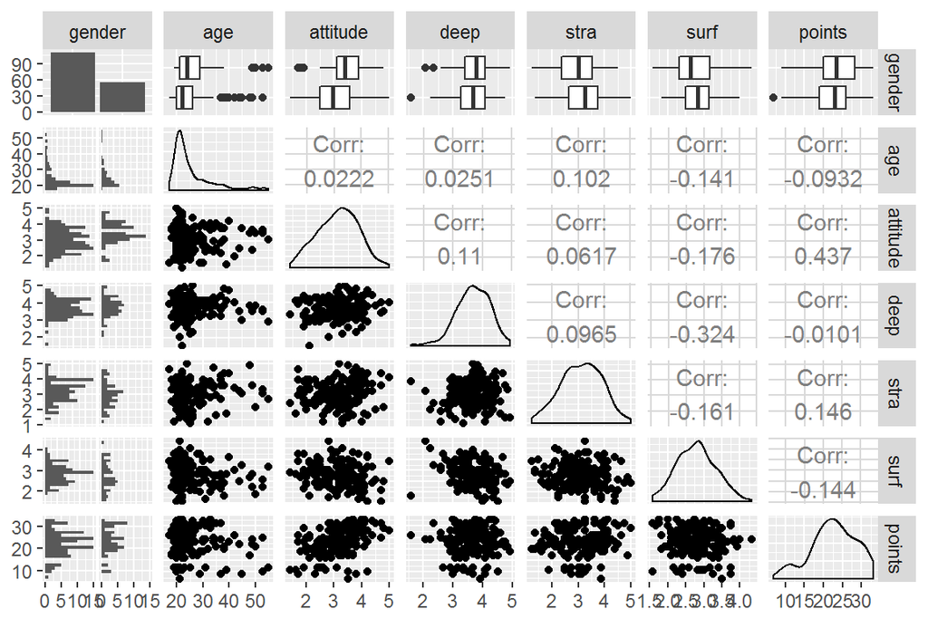

```
##  gender       age           attitude          deep            stra
##  F:110   Min.   :17.00   Min.   :1.400   Min.   :1.583   Min.   :1.250
##  M: 56   1st Qu.:21.00   1st Qu.:2.600   1st Qu.:3.333   1st Qu.:2.625
##          Median :22.00   Median :3.200   Median :3.667   Median :3.188
##          Mean   :25.51   Mean   :3.143   Mean   :3.680   Mean   :3.121
##          3rd Qu.:27.00   3rd Qu.:3.700   3rd Qu.:4.083   3rd Qu.:3.625
##          Max.   :55.00   Max.   :5.000   Max.   :4.917   Max.   :5.000
##       surf           points
##  Min.   :1.583   Min.   : 7.00
##  1st Qu.:2.417   1st Qu.:19.00
##  Median :2.833   Median :23.00
##  Mean   :2.787   Mean   :22.72
##  3rd Qu.:3.167   3rd Qu.:27.75
##  Max.   :4.333   Max.   :33.00
```

```
##
## Call:
## lm(formula = points ~ attitude + stra + age, data = lrn14)
##
## Residuals:
##      Min       1Q   Median       3Q      Max
## -18.1149  -3.2003   0.3303   3.4129  10.7599
##
## Coefficients:
##             Estimate Std. Error t value Pr(>|t|)
## (Intercept) 10.89543    2.64834   4.114 6.17e-05 ***
## attitude     3.48077    0.56220   6.191 4.72e-09 ***
## stra         1.00371    0.53434   1.878   0.0621 .
## age         -0.08822    0.05302  -1.664   0.0981 .
## ---
## Signif. codes:  0 '***' 0.001 '**' 0.01 '*' 0.05 '.' 0.1 ' ' 1
##
## Residual standard error: 5.26 on 162 degrees of freedom
## Multiple R-squared:  0.2182, Adjusted R-squared:  0.2037
## F-statistic: 15.07 on 3 and 162 DF,  p-value: 1.07e-08
```

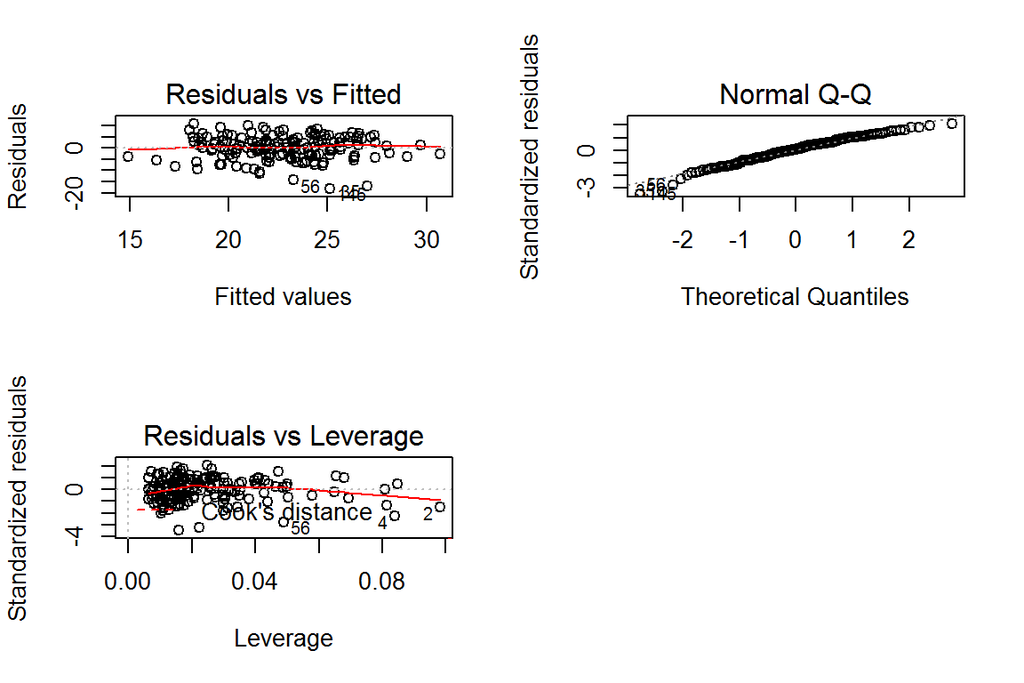

# Logistic Regression

## 1. Reading data

```
## [1] 382  35
```

```
## 'data.frame':    382 obs. of  35 variables:
##  $ school    : Factor w/ 2 levels "GP","MS": 1 1 1 1 1 1 1 1 1 1 ...
##  $ sex       : Factor w/ 2 levels "F","M": 1 1 1 1 1 2 2 1 2 2 ...
##  $ age       : int  18 17 15 15 16 16 16 17 15 15 ...
##  $ address   : Factor w/ 2 levels "R","U": 2 2 2 2 2 2 2 2 2 2 ...
##  $ famsize   : Factor w/ 2 levels "GT3","LE3": 1 1 2 1 1 2 2 1 2 1 ...
##  $ Pstatus   : Factor w/ 2 levels "A","T": 1 2 2 2 2 2 2 1 1 2 ...
##  $ Medu      : int  4 1 1 4 3 4 2 4 3 3 ...
##  $ Fedu      : int  4 1 1 2 3 3 2 4 2 4 ...
##  $ Mjob      : Factor w/ 5 levels "at_home","health",..: 1 1 1 2 3 4 3 3 4 3 ...
##  $ Fjob      : Factor w/ 5 levels "at_home","health",..: 5 3 3 4 3 3 3 5 3 3 ...
##  $ reason    : Factor w/ 4 levels "course","home",..: 1 1 3 2 2 4 2 2 2 2 ...
##  $ nursery   : Factor w/ 2 levels "no","yes": 2 1 2 2 2 2 2 2 2 2 ...
##  $ internet  : Factor w/ 2 levels "no","yes": 1 2 2 2 1 2 2 1 2 2 ...
##  $ guardian  : Factor w/ 3 levels "father","mother",..: 2 1 2 2 1 2 2 2 2 2 ...
```

[output cut: 21 more lines]

### Summary of data

This dataset has 382 rows and 35 variables. There is general information about the students: school they belong to, sex, age, address and family size. There is also information about their parents, allocation of hours towards travel to school and studytime, some personal information about what the student is otherwise occupied with, health status (including alcohol consumption) and grades for Math and Portugese across 2 periods.

## 2. Hypothesis

Hypotheses to be tested 1. alcohol use is associated with the quality of family relationships. 2. alcohol use is associated with student’s freetime. 3. alcohol use is associated with health. 4. alcohol use is associated with sex.

## 3. Variable means

```
## # A tibble: 2 × 5
##   high_use count mean_famrel mean_freetime mean_health
##      <lgl> <int>       <dbl>         <dbl>       <dbl>
## 1    FALSE   270    4.014815      3.125926    3.518519
## 2     TRUE   112    3.758929      3.455357    3.723214
```

### Summary

Here, we see that there are 270 cases of low alcohol use and 112 cases of high alcohol use (more than 2 on a scale of 1-5). freetime - free time after school (numeric: from 1 - very low to 5 - very high) famrel - quality of family relationships (numeric: from 1 - very bad to 5 - excellent) health - current health status (numeric: from 1 - very bad to 5 - very good)

In the group of high alcohol use, the mean of quality of family relationships is 3.7 and for the group with low alcohol use, the mean of quality of family relationships is 4.0. In general, it can be surmised that low alcohol use may be associated with better family relationships.

Amongst students with low alcohol use, there is less free time (mean = 3.12) compared to students with higher alcohol use who seem to have more free time (mean = 3.46). Interestingly, low alcohol consumption students seem to enjoy worse health (mean = 3.5) than students who drink more (mean = 3.72)

## 4. Variable means by sex

```
## Source: local data frame [4 x 6]
## Groups: sex [?]
##
##      sex high_use count mean_famrel mean_freetime mean_health
##   <fctr>    <lgl> <int>       <dbl>         <dbl>       <dbl>
## 1      F    FALSE   157    3.917197      2.929936    3.388535
## 2      F     TRUE    41    3.731707      3.341463    3.390244
## 3      M    FALSE   113    4.150442      3.398230    3.699115
## 4      M     TRUE    71    3.774648      3.521127    3.915493
```

### Summary

With regards to sex, 157 females consume low amounts of alcohol and 41 females consume high amounts of alcohol. In the group of females who drink more, family relationship is worse ( 3.73), they have more freetime (mean=3.34) and they enjoy better health (3.39) as compared to females who drink less.

In the male group, there are 113 males who drink less and 71 males who drink more. The group that drinks more has less quality family relationships (mean=3.77), more freetime (mean=3.52) and also enjoy better healht (3.91) as compared to males who drink less. Males with high alcohol use have more free time and better family relationships and enjoy better health than females with high alcohol use.

## 5. Boxplots for selected variables

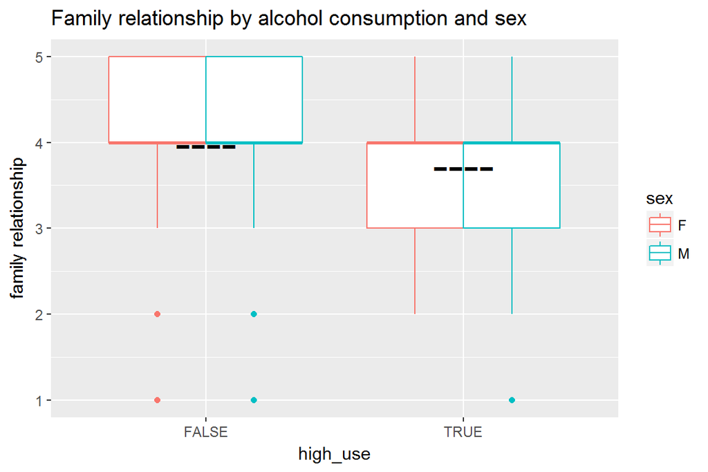

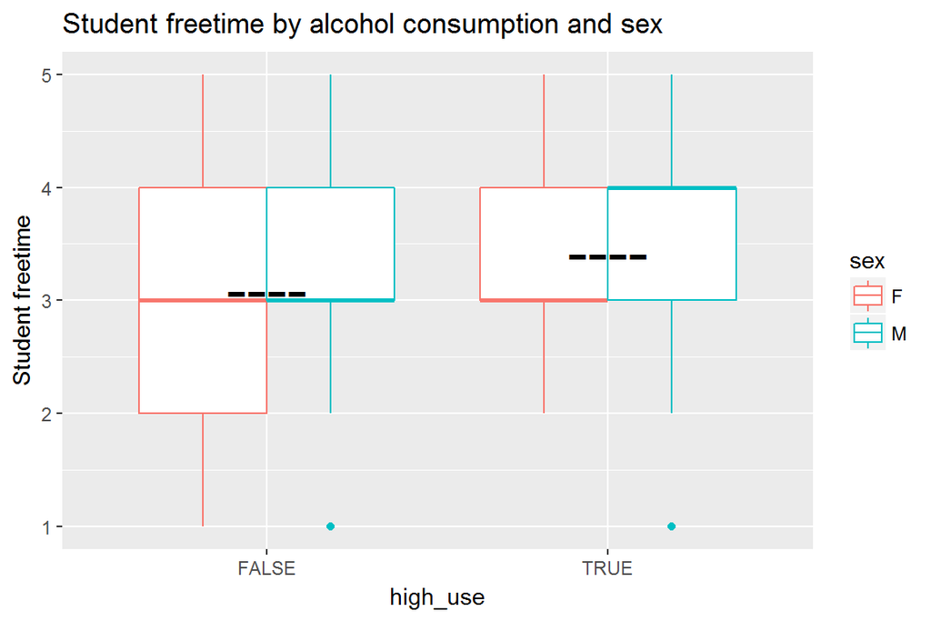

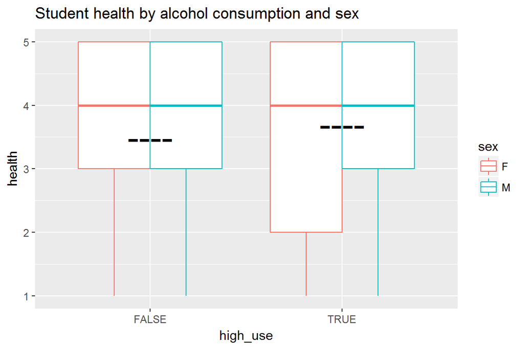

### Summary

The median for quality of family relationships is the same for both males and females across both groups of alcohol use (median = 4). The upper quartile value is 5 in both sexes for students with low alcohol use and 4 for students with high alcohol use. The lowest value for family relationship (ignoring the outliers) is 3 for students with low alcohol consumption and 2 for students with high alcohol consumption.

The median for student health is 4 for students with high and low alcohol use. Mean health is higher for students with high alcohol comsumption.

## 6. Barplots for selected variables

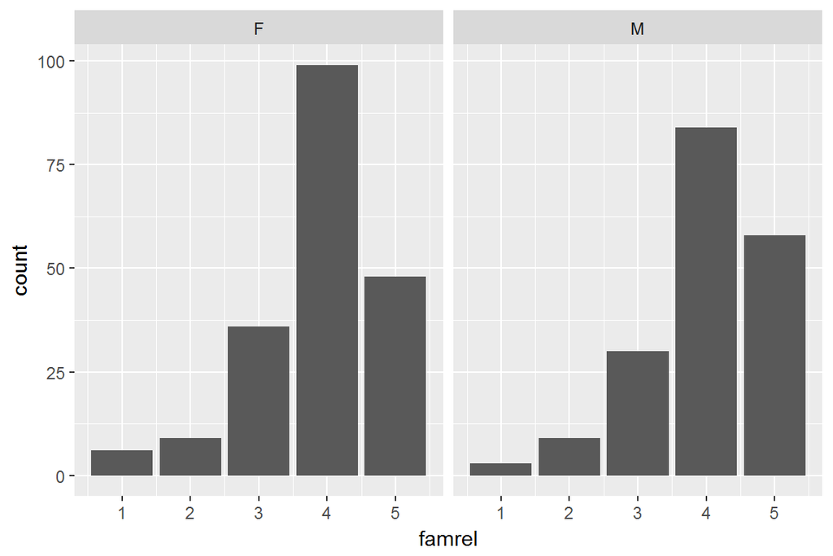

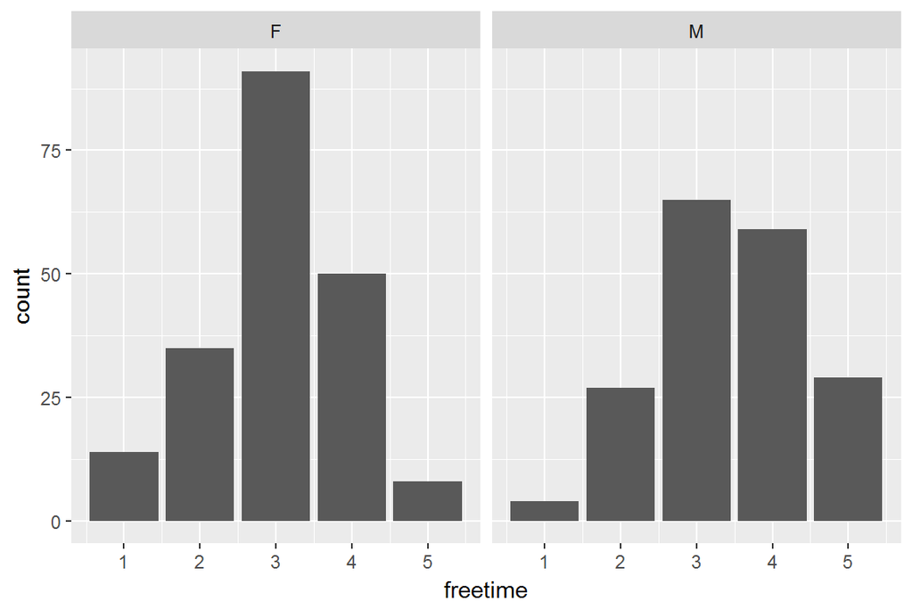

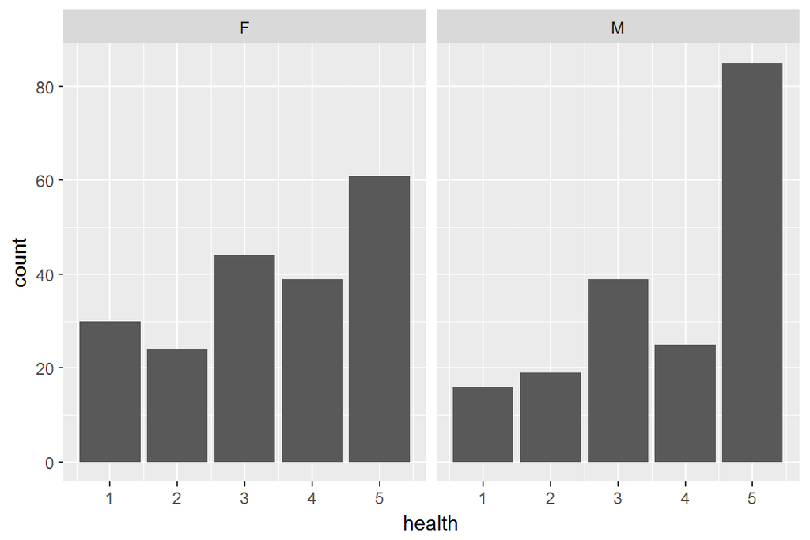

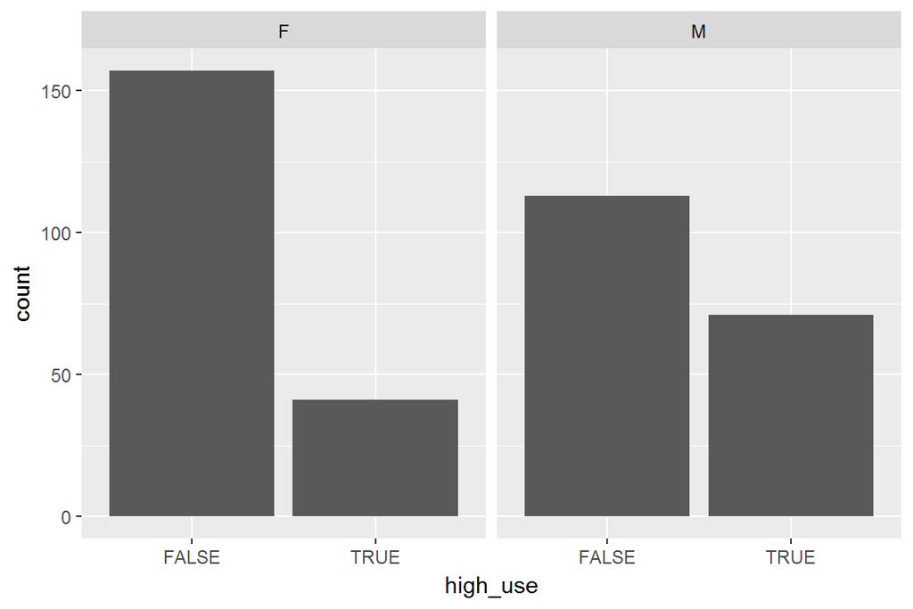

### Summary

The pattern for family relationship across sexes is the same. For freetime, the smallest number of females have the most freetime (5) and the smallest number of males have the lowest freetime (1). For health, the highest number of individuals have the healthiest status in both sexes. Across both sexes, there are more individuals with low alcohol use.

## 7. Regression model with selected variables (famrel + freetime + health + G1)

```
##
## Call:
## glm(formula = high_use ~ famrel + freetime + health + G1, family = "binomial",
##     data = alc)
##
## Deviance Residuals:
##     Min       1Q   Median       3Q      Max
## -1.4032  -0.8646  -0.6795   1.2523   2.1451
##
## Coefficients:
##             Estimate Std. Error z value Pr(>|z|)
## (Intercept) -0.38950    0.72807  -0.535 0.592670
## famrel      -0.38713    0.12645  -3.062 0.002202 **
## freetime     0.41644    0.12361   3.369 0.000755 ***
## health       0.11004    0.08564   1.285 0.198823
## G1          -0.07059    0.03575  -1.975 0.048308 *
## ---
## Signif. codes:  0 '***' 0.001 '**' 0.01 '*' 0.05 '.' 0.1 ' ' 1
##
## (Dispersion parameter for binomial family taken to be 1)
##
##     Null deviance: 462.21  on 381  degrees of freedom
## Residual deviance: 438.17  on 377  degrees of freedom
## AIC: 448.17
##
## Number of Fisher Scoring iterations: 4
```

```
## (Intercept)      famrel    freetime      health          G1
## -0.38949538 -0.38713461  0.41643988  0.11003943 -0.07059407
```

```
##                    OR     2.5 %    97.5 %
## (Intercept) 0.6773986 0.1612150 2.8229159
## famrel      0.6789997 0.5284166 0.8690777
## freetime    1.5165528 1.1947907 1.9419266
## health      1.1163221 0.9456039 1.3238873
## G1          0.9318401 0.8678501 0.9987250
```

### Summary

Family relationship and first period scores are negatively associated with alcohol consumption and student freetime is positively associated with alcohol consumption. There is no association between student health and alcohol consumption.

## 8. Regression model with selected variables (famrel + freetime + sex + G1)

```
##
## Call:
## glm(formula = high_use ~ famrel + freetime + sex + G1, family = "binomial",
##     data = alc)
##
## Deviance Residuals:
##     Min       1Q   Median       3Q      Max
## -1.4430  -0.8247  -0.6293   1.1380   2.2757
##
## Coefficients:
##             Estimate Std. Error z value Pr(>|z|)
## (Intercept)  0.06816    0.68428   0.100 0.920658
## famrel      -0.39708    0.12768  -3.110 0.001871 **
## freetime     0.33524    0.12611   2.658 0.007851 **
## sexM         0.91114    0.24671   3.693 0.000222 ***
## G1          -0.09231    0.03668  -2.517 0.011842 *
## ---
## Signif. codes:  0 '***' 0.001 '**' 0.01 '*' 0.05 '.' 0.1 ' ' 1
##
## (Dispersion parameter for binomial family taken to be 1)
##
##     Null deviance: 462.21  on 381  degrees of freedom
## Residual deviance: 425.75  on 377  degrees of freedom
## AIC: 435.75
##
## Number of Fisher Scoring iterations: 4
```

```
## (Intercept)      famrel    freetime        sexM          G1
##  0.06815784 -0.39708257  0.33524348  0.91114399 -0.09231233
```

```
##                    OR     2.5 %    97.5 %
## (Intercept) 1.0705343 0.2775903 4.0995202
## famrel      0.6722785 0.5218210 0.8623343
## freetime    1.3982808 1.0955471 1.7982556
## sexM        2.4871662 1.5412350 4.0616884
## G1          0.9118203 0.8474427 0.9788147
```

### Summary

Family relationships and period 1 scores are negatively associated with alcohol use i.e. the lower the quality of family relationships, the higher the alcohol use. The most significant association is sex. With sex=females as the baseline in the intercept, the coefficient for males is 0.06 + 0.91=0.97. In summary, family relationships, student freetime, sex and period 1 scores are are significantly associated with high alcohol use.

## 9. predictions versus the actual values

```
##
##         FALSE TRUE
##   FALSE   250   20
##   TRUE     94   18
```

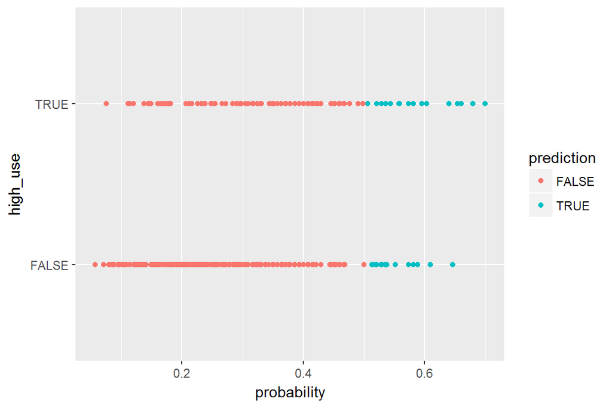

## 10. Percentage predictions accuracy

```
##         prediction
## high_use      FALSE       TRUE        Sum
##    FALSE 0.65445026 0.05235602 0.70680628
##    TRUE  0.24607330 0.04712042 0.29319372
##    Sum   0.90052356 0.09947644 1.00000000
```

### Summary

Predition error is 30% (0.25 + 0.05) of the time. ***

# Clustering and classification

*We learnt how to perform scaling of data so that they are more comparable. We also did linear discriminate analysis and k-means clustering .*

## BOSTON Data Variables

```
## 'data.frame':    506 obs. of  14 variables:
##  $ crim   : num  0.00632 0.02731 0.02729 0.03237 0.06905 ...
##  $ zn     : num  18 0 0 0 0 0 12.5 12.5 12.5 12.5 ...
##  $ indus  : num  2.31 7.07 7.07 2.18 2.18 2.18 7.87 7.87 7.87 7.87 ...
##  $ chas   : int  0 0 0 0 0 0 0 0 0 0 ...
##  $ nox    : num  0.538 0.469 0.469 0.458 0.458 0.458 0.524 0.524 0.524 0.524 ...
##  $ rm     : num  6.58 6.42 7.18 7 7.15 ...
##  $ age    : num  65.2 78.9 61.1 45.8 54.2 58.7 66.6 96.1 100 85.9 ...
##  $ dis    : num  4.09 4.97 4.97 6.06 6.06 ...
##  $ rad    : int  1 2 2 3 3 3 5 5 5 5 ...
##  $ tax    : num  296 242 242 222 222 222 311 311 311 311 ...
##  $ ptratio: num  15.3 17.8 17.8 18.7 18.7 18.7 15.2 15.2 15.2 15.2 ...
##  $ black  : num  397 397 393 395 397 ...
##  $ lstat  : num  4.98 9.14 4.03 2.94 5.33 ...
##  $ medv   : num  24 21.6 34.7 33.4 36.2 28.7 22.9 27.1 16.5 18.9 ...
```

```
## [1] "Summary before scaling"
```

```
##       crim                zn             indus            chas
##  Min.   : 0.00632   Min.   :  0.00   Min.   : 0.46   Min.   :0.00000
##  1st Qu.: 0.08204   1st Qu.:  0.00   1st Qu.: 5.19   1st Qu.:0.00000
##  Median : 0.25651   Median :  0.00   Median : 9.69   Median :0.00000
##  Mean   : 3.61352   Mean   : 11.36   Mean   :11.14   Mean   :0.06917
##  3rd Qu.: 3.67708   3rd Qu.: 12.50   3rd Qu.:18.10   3rd Qu.:0.00000
##  Max.   :88.97620   Max.   :100.00   Max.   :27.74   Max.   :1.00000
##       nox               rm             age              dis
##  Min.   :0.3850   Min.   :3.561   Min.   :  2.90   Min.   : 1.130
##  1st Qu.:0.4490   1st Qu.:5.886   1st Qu.: 45.02   1st Qu.: 2.100
##  Median :0.5380   Median :6.208   Median : 77.50   Median : 3.207
##  Mean   :0.5547   Mean   :6.285   Mean   : 68.57   Mean   : 3.795
##  3rd Qu.:0.6240   3rd Qu.:6.623   3rd Qu.: 94.08   3rd Qu.: 5.188
##  Max.   :0.8710   Max.   :8.780   Max.   :100.00   Max.   :12.127
##       rad              tax           ptratio          black
##  Min.   : 1.000   Min.   :187.0   Min.   :12.60   Min.   :  0.32
##  1st Qu.: 4.000   1st Qu.:279.0   1st Qu.:17.40   1st Qu.:375.38
##  Median : 5.000   Median :330.0   Median :19.05   Median :391.44
##  Mean   : 9.549   Mean   :408.2   Mean   :18.46   Mean   :356.67
##  3rd Qu.:24.000   3rd Qu.:666.0   3rd Qu.:20.20   3rd Qu.:396.23
##  Max.   :24.000   Max.   :711.0   Max.   :22.00   Max.   :396.90
##      lstat            medv
##  Min.   : 1.73   Min.   : 5.00
##  1st Qu.: 6.95   1st Qu.:17.02
##  Median :11.36   Median :21.20
##  Mean   :12.65   Mean   :22.53
##  3rd Qu.:16.95   3rd Qu.:25.00
##  Max.   :37.97   Max.   :50.00
```

```
## [1] 506  14
```

The Boston dataset has 506 rows and 14 variables. This dataset has information about the city of Boston. Information includes crime rate (crim),information about residents: proportion of residential land (zn), average number of rooms per dwelling (rm), proportion of owner-occupied homes (age), value of owner-occupied homes (medv), percentage of black people (black) and lowers status of population (lstat). There is also information about: business areas (indus), distance to employment centers (dis), pupil-teacher ration (ptratio), property tax(tax) and accessibility to highway (rad). All data are of type num except for chas and rad which are integers.

## Relationship between variables

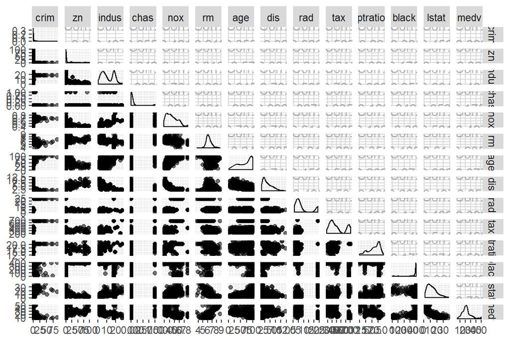

The Boston dataset plot shows that most of the distributions of the variables are not normal.

```
##          crim    zn indus  chas   nox    rm   age   dis   rad   tax
## crim     1.00 -0.20  0.41 -0.06  0.42 -0.22  0.35 -0.38  0.63  0.58
## zn      -0.20  1.00 -0.53 -0.04 -0.52  0.31 -0.57  0.66 -0.31 -0.31
## indus    0.41 -0.53  1.00  0.06  0.76 -0.39  0.64 -0.71  0.60  0.72
## chas    -0.06 -0.04  0.06  1.00  0.09  0.09  0.09 -0.10 -0.01 -0.04
## nox      0.42 -0.52  0.76  0.09  1.00 -0.30  0.73 -0.77  0.61  0.67
## rm      -0.22  0.31 -0.39  0.09 -0.30  1.00 -0.24  0.21 -0.21 -0.29
## age      0.35 -0.57  0.64  0.09  0.73 -0.24  1.00 -0.75  0.46  0.51
## dis     -0.38  0.66 -0.71 -0.10 -0.77  0.21 -0.75  1.00 -0.49 -0.53
## rad      0.63 -0.31  0.60 -0.01  0.61 -0.21  0.46 -0.49  1.00  0.91
## tax      0.58 -0.31  0.72 -0.04  0.67 -0.29  0.51 -0.53  0.91  1.00
## ptratio  0.29 -0.39  0.38 -0.12  0.19 -0.36  0.26 -0.23  0.46  0.46
## black   -0.39  0.18 -0.36  0.05 -0.38  0.13 -0.27  0.29 -0.44 -0.44
## lstat    0.46 -0.41  0.60 -0.05  0.59 -0.61  0.60 -0.50  0.49  0.54
## medv    -0.39  0.36 -0.48  0.18 -0.43  0.70 -0.38  0.25 -0.38 -0.47
##         ptratio black lstat  medv
## crim       0.29 -0.39  0.46 -0.39
## zn        -0.39  0.18 -0.41  0.36
## indus      0.38 -0.36  0.60 -0.48
## chas      -0.12  0.05 -0.05  0.18
## nox        0.19 -0.38  0.59 -0.43
## rm        -0.36  0.13 -0.61  0.70
## age        0.26 -0.27  0.60 -0.38
## dis       -0.23  0.29 -0.50  0.25
## rad        0.46 -0.44  0.49 -0.38
## tax        0.46 -0.44  0.54 -0.47
## ptratio    1.00 -0.18  0.37 -0.51
## black     -0.18  1.00 -0.37  0.33
## lstat      0.37 -0.37  1.00 -0.74
## medv      -0.51  0.33 -0.74  1.00
```

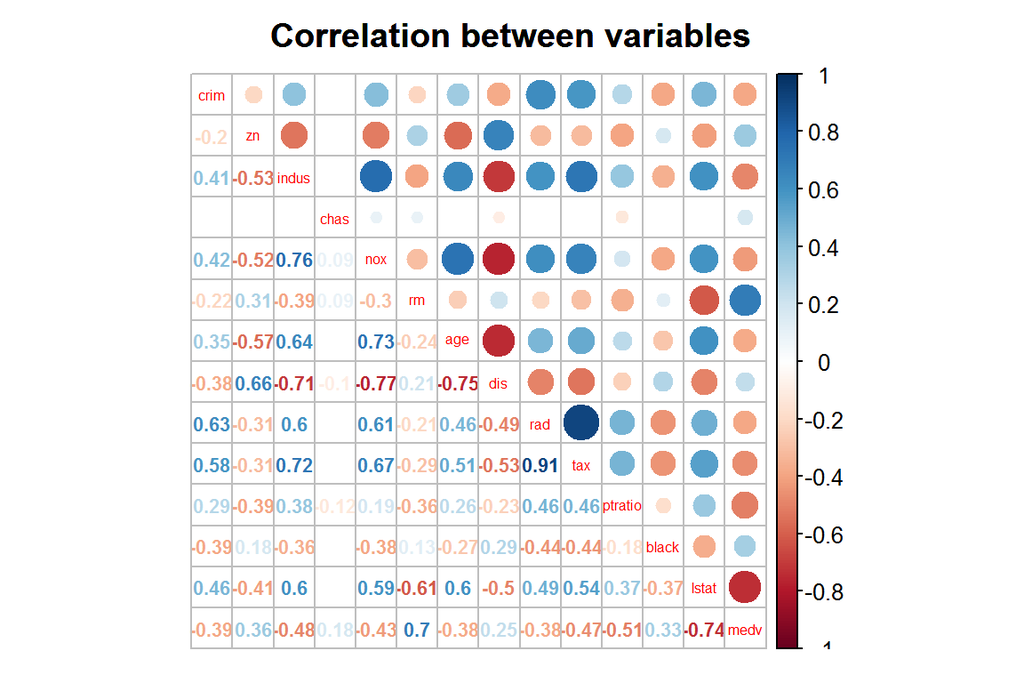

## Data Standardization

Summary after scaling of data

```
##       crim                 zn               indus
##  Min.   :-0.419367   Min.   :-0.48724   Min.   :-1.5563
##  1st Qu.:-0.410563   1st Qu.:-0.48724   1st Qu.:-0.8668
##  Median :-0.390280   Median :-0.48724   Median :-0.2109
##  Mean   : 0.000000   Mean   : 0.00000   Mean   : 0.0000
##  3rd Qu.: 0.007389   3rd Qu.: 0.04872   3rd Qu.: 1.0150
##  Max.   : 9.924110   Max.   : 3.80047   Max.   : 2.4202
##       chas              nox                rm               age
##  Min.   :-0.2723   Min.   :-1.4644   Min.   :-3.8764   Min.   :-2.3331
##  1st Qu.:-0.2723   1st Qu.:-0.9121   1st Qu.:-0.5681   1st Qu.:-0.8366
##  Median :-0.2723   Median :-0.1441   Median :-0.1084   Median : 0.3171
##  Mean   : 0.0000   Mean   : 0.0000   Mean   : 0.0000   Mean   : 0.0000
##  3rd Qu.:-0.2723   3rd Qu.: 0.5981   3rd Qu.: 0.4823   3rd Qu.: 0.9059
##  Max.   : 3.6648   Max.   : 2.7296   Max.   : 3.5515   Max.   : 1.1164
##       dis               rad               tax             ptratio
##  Min.   :-1.2658   Min.   :-0.9819   Min.   :-1.3127   Min.   :-2.7047
##  1st Qu.:-0.8049   1st Qu.:-0.6373   1st Qu.:-0.7668   1st Qu.:-0.4876
##  Median :-0.2790   Median :-0.5225   Median :-0.4642   Median : 0.2746
##  Mean   : 0.0000   Mean   : 0.0000   Mean   : 0.0000   Mean   : 0.0000
##  3rd Qu.: 0.6617   3rd Qu.: 1.6596   3rd Qu.: 1.5294   3rd Qu.: 0.8058
##  Max.   : 3.9566   Max.   : 1.6596   Max.   : 1.7964   Max.   : 1.6372
##      black             lstat              medv
##  Min.   :-3.9033   Min.   :-1.5296   Min.   :-1.9063
##  1st Qu.: 0.2049   1st Qu.:-0.7986   1st Qu.:-0.5989
##  Median : 0.3808   Median :-0.1811   Median :-0.1449
##  Mean   : 0.0000   Mean   : 0.0000   Mean   : 0.0000
##  3rd Qu.: 0.4332   3rd Qu.: 0.6024   3rd Qu.: 0.2683
##  Max.   : 0.4406   Max.   : 3.5453   Max.   : 2.9865
```

```
## [1] "matrix"
```

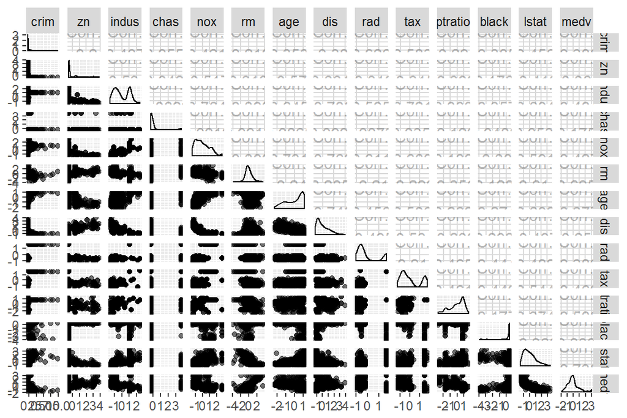

```
##      Min.   1st Qu.    Median      Mean   3rd Qu.      Max.
## -0.419400 -0.410600 -0.390300  0.000000  0.007389  9.924000
```

```
##           0%          25%          50%          75%         100%
## -0.419366929 -0.410563278 -0.390280295  0.007389247  9.924109610
```

```
## crime
##      low  med_low med_high     high
##      127      126      126      127
```

```
##           zn      indus       chas        nox        rm        age
## 1  0.2845483 -1.2866362 -0.2723291 -0.1440749 0.4132629 -0.1198948
## 2 -0.4872402 -0.5927944 -0.2723291 -0.7395304 0.1940824  0.3668034
## 3 -0.4872402 -0.5927944 -0.2723291 -0.7395304 1.2814456 -0.2655490
## 4 -0.4872402 -1.3055857 -0.2723291 -0.8344581 1.0152978 -0.8090878
## 5 -0.4872402 -1.3055857 -0.2723291 -0.8344581 1.2273620 -0.5106743
## 6 -0.4872402 -1.3055857 -0.2723291 -0.8344581 0.2068916 -0.3508100
##        dis        rad        tax    ptratio     black      lstat
## 1 0.140075 -0.9818712 -0.6659492 -1.4575580 0.4406159 -1.0744990
## 2 0.556609 -0.8670245 -0.9863534 -0.3027945 0.4406159 -0.4919525
## 3 0.556609 -0.8670245 -0.9863534 -0.3027945 0.3960351 -1.2075324
## 4 1.076671 -0.7521778 -1.1050216  0.1129203 0.4157514 -1.3601708
## 5 1.076671 -0.7521778 -1.1050216  0.1129203 0.4406159 -1.0254866
## 6 1.076671 -0.7521778 -1.1050216  0.1129203 0.4101651 -1.0422909
##         medv crime
## 1  0.1595278   low
## 2 -0.1014239   low
## 3  1.3229375   low
## 4  1.1815886   low
## 5  1.4860323   low
## 6  0.6705582   low
```

## LDA Analysis

We now need to split out data into test and training. And we do lda on the train data.

```
## Call:
## lda(crime ~ ., data = train)
##
## Prior probabilities of groups:
##       low   med_low  med_high      high
## 0.2475248 0.2450495 0.2574257 0.2500000
##
## Group means:
##                   zn      indus        chas        nox         rm
## low       1.00145399 -0.8794269 -0.07547406 -0.8769166  0.3775536
## med_low  -0.08380531 -0.2879539  0.04582045 -0.5632734 -0.1353497
## med_high -0.37922279  0.1742384  0.14409500  0.3718870  0.1295298
## high     -0.48724019  1.0171306 -0.03844192  1.0512792 -0.5067908
##                 age        dis        rad        tax    ptratio
## low      -0.9420950  0.9109817 -0.6890121 -0.7169765 -0.3882470
## med_low  -0.3398653  0.3527128 -0.5491659 -0.4480911 -0.0849058
## med_high  0.3580929 -0.3944738 -0.3888647 -0.2825025 -0.2672633
## high      0.8536775 -0.8738047  1.6379981  1.5139626  0.7806252
##                black       lstat        medv
## low       0.37920061 -0.75009342  0.44276912
## med_low   0.34428025 -0.12788929 -0.01762503
## med_high  0.07670104 -0.03810382  0.20730621
## high     -0.71775124  0.95454180 -0.69868467
##
## Coefficients of linear discriminants:
##                 LD1         LD2         LD3
## zn       0.13553715  0.75426912 -0.96918416
## indus   -0.01572093 -0.22271262  0.15707653
## chas    -0.08044497  0.02020192  0.15300482
## nox      0.40168262 -0.74158954 -1.35818159
## rm      -0.10747602 -0.10814040 -0.12632964
## age      0.30619209 -0.28699519  0.02062557
## dis     -0.07445973 -0.22685490  0.25161710
## rad      3.02575484  0.91646629 -0.13309238
## tax     -0.05097713 -0.01565979  0.69520883
## ptratio  0.10696358  0.04718797 -0.33736591
## black   -0.13633290  0.02983801  0.16811042
## lstat    0.22128296 -0.21285045  0.37836561
## medv     0.19524985 -0.48733456 -0.22009805
##
## Proportion of trace:
##    LD1    LD2    LD3
## 0.9431 0.0427 0.0142
```

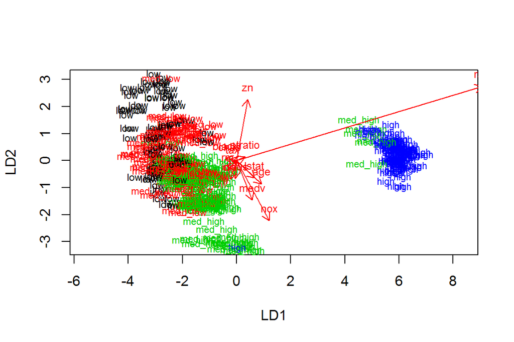

We now use the model to predict the crime classes in the test data.

```
##           predicted
## correct    low med_low med_high high
##   low       15      10        2    0
##   med_low    4      16        7    0
##   med_high   0      10       12    0
##   high       0       0        0   26
```

## k-means Clustering.

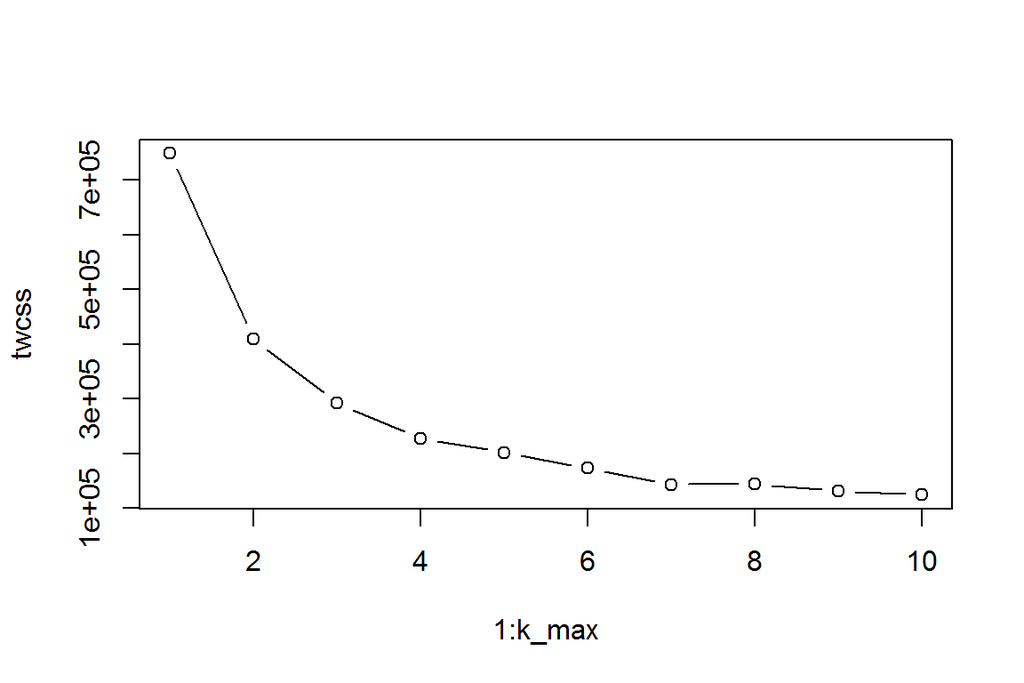

The plot shows that 3 clusters is ideal.

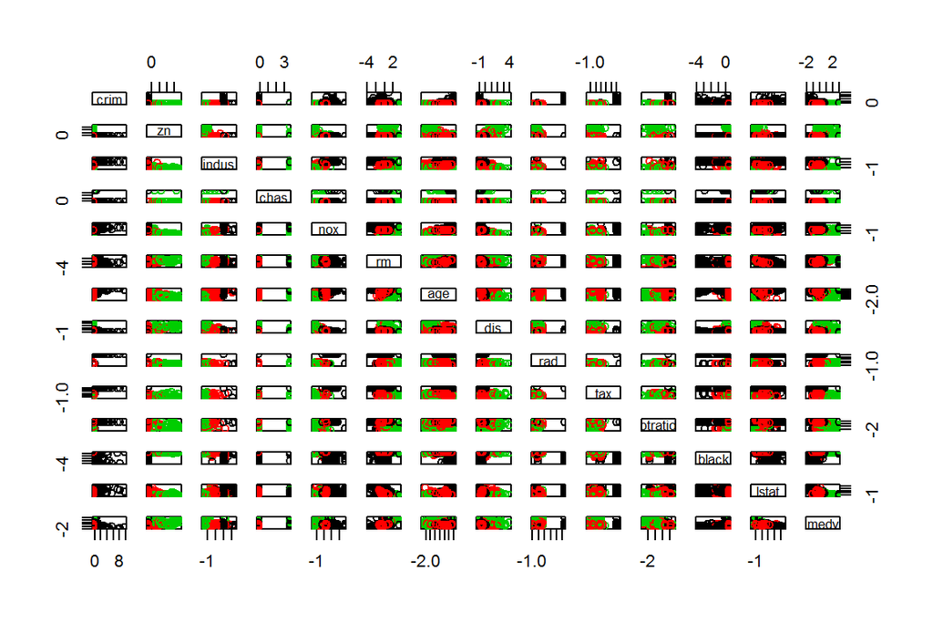

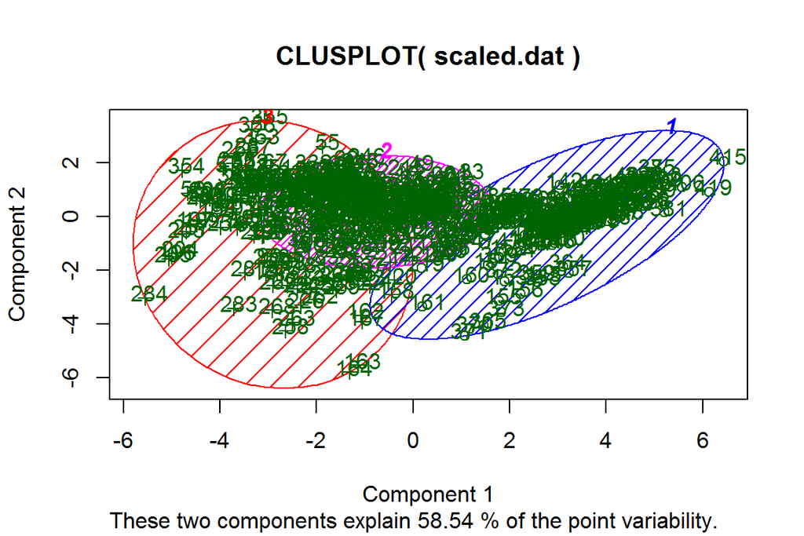

## Checking prediction for clusters (not for crime class!)

```
## Call:
## lda(cluster ~ ., data = train)
##
## Prior probabilities of groups:
##         1         2         3
## 0.3514851 0.4430693 0.2054455
##
## Group means:
##         crim         zn      indus        chas        nox         rm
## 1  0.8280037 -0.4872402  1.0936257  0.08810969  1.0909575 -0.4456886
## 2 -0.3874714 -0.2342890 -0.4456042 -0.27232907 -0.4741378 -0.1140076
## 3 -0.3896995  1.2162220 -0.8766851  0.43919507 -0.7176960  1.0668263
##          age        dis        rad        tax      ptratio      black
## 1  0.8047417 -0.8568829  1.1662474  1.2122679  0.589463582 -0.6339906
## 2 -0.2914091  0.2748787 -0.5885694 -0.6417183 -0.008362071  0.3180399
## 3 -0.7102159  0.7686246 -0.5916691 -0.6108328 -0.902714990  0.3398897
##        lstat        medv
## 1  0.8710141 -0.65816683
## 2 -0.2451151 -0.02391592
## 3 -0.8568202  1.15250667
##
## Coefficients of linear discriminants:
##                 LD1         LD2
## crim     0.02530217  0.16331494
## zn      -0.21496490  1.23494436
## indus   -0.79168768  0.03011042
## chas    -0.01340155  0.51336116
## nox     -0.90340895  0.34597557
## rm       0.08590185  0.56109959
## age      0.13533879 -0.08768066
## dis     -0.04293457  0.09789858
## rad     -0.65728244 -0.26782864
## tax     -0.69153989  0.67684361
## ptratio -0.23813439 -0.06056914
## black    0.09130726 -0.07287952
## lstat   -0.26761628  0.62771575
## medv    -0.03315434  0.76660056
##
## Proportion of trace:
##    LD1    LD2
## 0.8102 0.1898
```

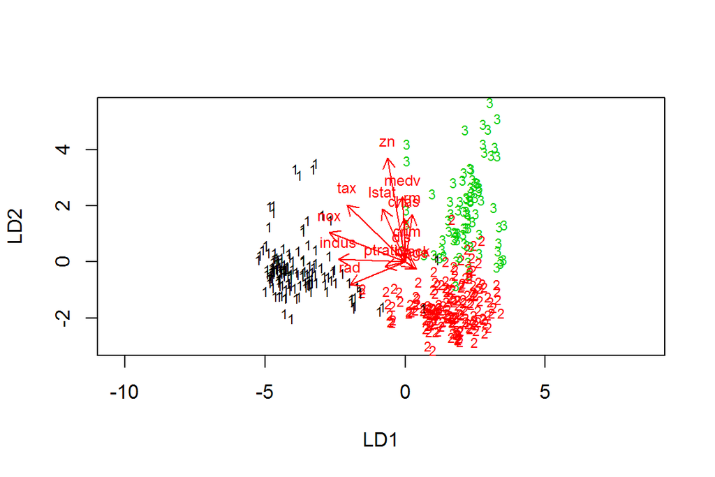

# Dimension Reduction

This week, we learnt how to do dimension reduction. I did not do the last part- no 11.

## Summary of data

```
## [1] 154   8
```

```
## 'data.frame':    154 obs. of  8 variables:
##  $ ï..gii_FM_edu_rat: num  1.007 0.997 0.983 0.989 0.969 ...
##  $ gii_FM_work_rat  : num  0.891 0.819 0.825 0.884 0.829 ...
##  $ exp_edu          : num  17.5 20.2 15.8 18.7 17.9 16.5 18.6 16.5 15.9 19.2 ...
##  $ life_exp         : num  81.6 82.4 83 80.2 81.6 80.9 80.9 79.1 82 81.8 ...
##  $ GNI              : int  64992 42261 56431 44025 45435 43919 39568 52947 42155 32689 ...
##  $ mat_mor_rat      : int  4 6 6 5 6 7 9 28 11 8 ...
##  $ adol_birth_rat   : num  7.8 12.1 1.9 5.1 6.2 3.8 8.2 31 14.5 25.3 ...
##  $ fem_parlimen     : num  39.6 30.5 28.5 38 36.9 36.9 19.9 19.4 28.2 31.4 ...
```

There are 154 rows and 8 variables:

- gii_FM_edu_rat: ratio of females over males with at least secondary education
- gii_FM_work_rat : ratio of females over males who work
- exp_edu : Expected years of schooling
- life_exp : Life expectancy at birth
- GNI : Gross National Income per capita
- mat_mor_rat : Maternal mortality ratio
- adol_birth_rat : Adolescent birth rate
- fem_parlimen : percentage of females in parlimen

## Variable correlation

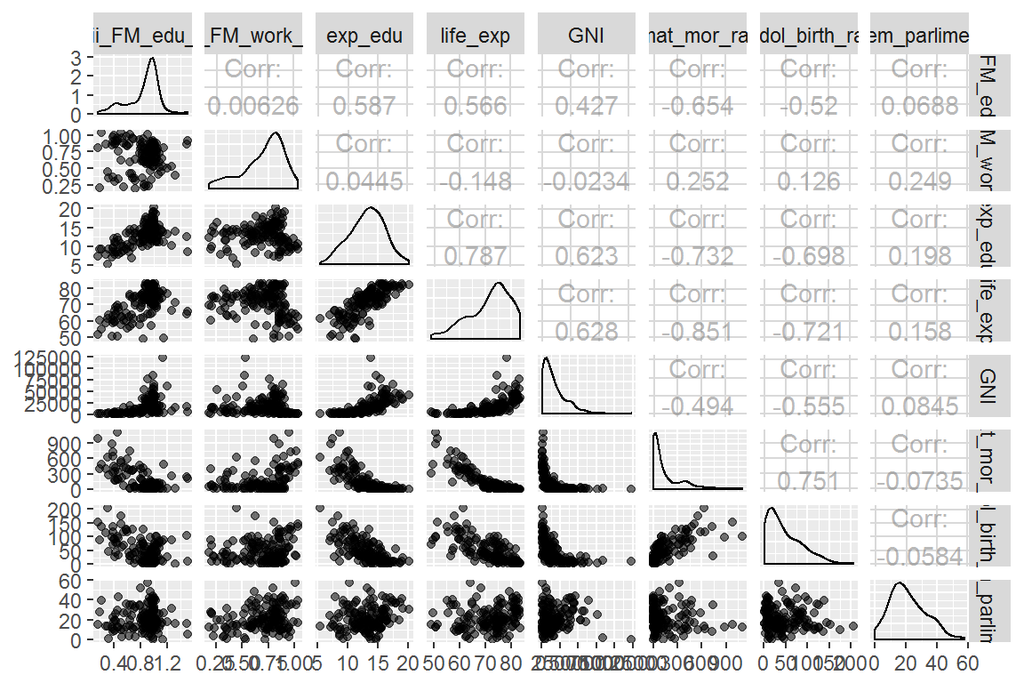

The dataset plot shows that most of the distributions of the variables are not normal.

```
##                   ï..gii_FM_edu_rat gii_FM_work_rat exp_edu life_exp   GNI
## ï..gii_FM_edu_rat              1.00            0.01    0.59     0.57  0.43
## gii_FM_work_rat                0.01            1.00    0.04    -0.15 -0.02
## exp_edu                        0.59            0.04    1.00     0.79  0.62
## life_exp                       0.57           -0.15    0.79     1.00  0.63
## GNI                            0.43           -0.02    0.62     0.63  1.00
## mat_mor_rat                   -0.65            0.25   -0.73    -0.85 -0.49
## adol_birth_rat                -0.52            0.13   -0.70    -0.72 -0.55
## fem_parlimen                   0.07            0.25    0.20     0.16  0.08
##                   mat_mor_rat adol_birth_rat fem_parlimen
## ï..gii_FM_edu_rat       -0.65          -0.52         0.07
## gii_FM_work_rat          0.25           0.13         0.25
## exp_edu                 -0.73          -0.70         0.20
## life_exp                -0.85          -0.72         0.16
## GNI                     -0.49          -0.55         0.08
## mat_mor_rat              1.00           0.75        -0.07
## adol_birth_rat           0.75           1.00        -0.06
## fem_parlimen            -0.07          -0.06         1.00
```

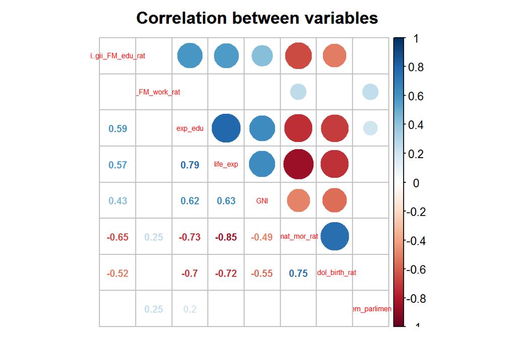

The table above shows the correlations between the variables. The correlation plot below it shows the value of the above correlations with circles: the bigger the circle, the higher the correlation. Only significant (p<0.05) correlations are shown.

There is a high, significant correlation between life expectancy and expected education (0.79) and expected education and GNI (0.62). There is also a high negative correlation between expected education (-0.73) and adolescence birth rate (-0.7). Life expectancy also has a high positive correlation (0.63) with GNI. There is also a high negative correlation between life expectancy and maternal mortality rate (-0.85) and life expectancy and adolescence birth rate (-0.72). There is also a significant correlation between GNI and adolescence birth rate (-0.55) and maternal mortality rate and adolescence birth rate (0.75).

## PCA with unscaled data

```
## Importance of components:
##                              PC1      PC2   PC3   PC4   PC5   PC6    PC7
## Standard deviation     1.857e+04 181.7501 25.27 11.46 3.777 1.567 0.1914
## Proportion of Variance 9.999e-01   0.0001  0.00  0.00 0.000 0.000 0.0000
## Cumulative Proportion  9.999e-01   1.0000  1.00  1.00 1.000 1.000 1.0000
##                           PC8
## Standard deviation     0.1592
## Proportion of Variance 0.0000
## Cumulative Proportion  1.0000
```

```
## PC1 PC2 PC3 PC4 PC5 PC6 PC7 PC8
## 100   0   0   0   0   0   0   0
```

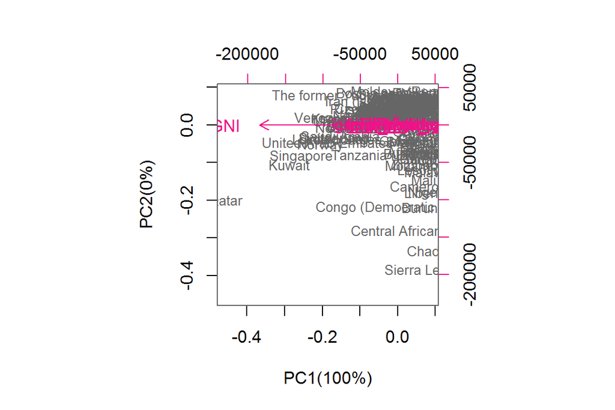

The plot shows that 1 PC is enough to capture almost 100% of the variation in the data. The biplot shows that countries that cluster together have high correlations.

## PCA with scaled data

```
## Importance of components:
##                           PC1    PC2     PC3     PC4     PC5     PC6
## Standard deviation     2.0642 1.1414 0.87702 0.78089 0.66499 0.54362
## Proportion of Variance 0.5326 0.1628 0.09615 0.07622 0.05528 0.03694
## Cumulative Proportion  0.5326 0.6955 0.79163 0.86785 0.92313 0.96007
##                            PC7     PC8
## Standard deviation     0.45969 0.32885
## Proportion of Variance 0.02641 0.01352
## Cumulative Proportion  0.98648 1.00000
```

```
##  PC1  PC2  PC3  PC4  PC5  PC6  PC7  PC8
## 53.3 16.3  9.6  7.6  5.5  3.7  2.6  1.4
```

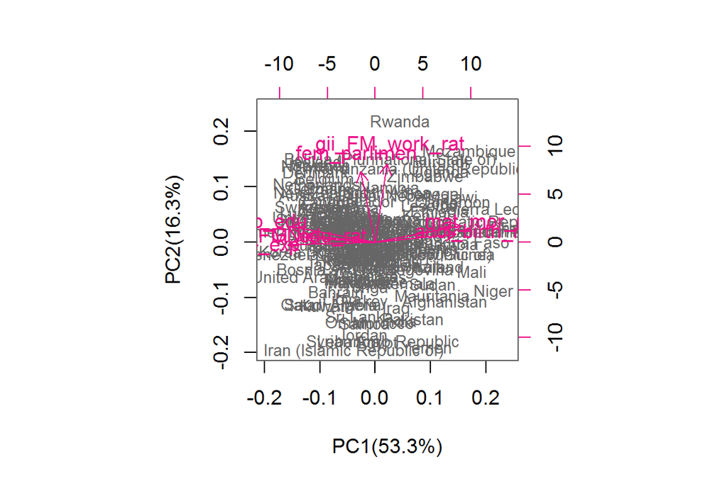

The scaled data shows that females in parlimen are not highly correlated with maternal mortality rate as well as adoscelence birth rate. There is also negative correlation between expected education and life expectancy with maternal mortality ratio aand adolescence birth rate. The countries that are closer together are more correlated.